# Wine_Clustering_Project

Abdukholik_Tukhtamishev

2025-01-07

# About dataset

The Wine Dataset you’re working with is a well-known dataset from the UCI Machine Learning Repository and originates from a study conducted by Forina et al. in 1986. The study, titled *“Multivariate Data Analysis as a Discriminating Method of the Origin of Wines,”* was published in the journal *Vitis*. This research aimed to distinguish wines based on their chemical composition, using multivariate data analysis to determine the geographical origin of the wines.

The dataset contains 178 samples of wines, divided into three classes corresponding to different grape varieties—Barolo, Grignolino, and Barbera. Each sample includes chemical properties such as alcohol content, malic acid, ash, magnesium, flavonoids, and proline, among others. The primary goal of the original research was to analyze and classify wines according to their characteristics.

This dataset has since been widely used in machine learning and statistics for tasks such as classification, clustering, and dimensionality reduction. It is particularly valuable for demonstrating methods like Principal Component Analysis (PCA) and K-means clustering. To further explore the dataset, you can review the original publication or its listing in the UCI Machine Learning Repository.

[Link to paper](https://ojs.openagrar.de/index.php/VITIS/article/view/5950)

# About my project

The goal of this project is to identify natural groupings or clusters of wines based on key factors that influence consumer preferences, such as flavor profile, strength, and appearance. By performing clustering using important features, I aim to uncover distinct wine categories that could align with customer taste preferences or market segments, enabling a better understanding of the dataset structure.

### Codes and Plots

```r
# Packages
library(cluster)
library(gridExtra)
library(corrplot)
library(factoextra)
library(tidyverse)
# Working directory
setwd("E:/UWarsaw/unsupervised_learning/USL_Project/Clustering")

# Import dataset
wine <- read.csv("E:/UWarsaw/unsupervised_learning/USL_Project/Clustering/wine-clustering.csv")

# General observation
colSums(is.na(wine)) # Checking for empty cells
```

```
##              Alcohol           Malic_Acid                  Ash
##                    0                    0                    0
##         Ash_Alcanity            Magnesium        Total_Phenols
##                    0                    0                    0
##           Flavanoids Nonflavanoid_Phenols      Proanthocyanins
##                    0                    0                    0
##      Color_Intensity                  Hue                OD280
##                    0                    0                    0
##              Proline
##                    0
```

```r
head(wine)
```

```
##   Alcohol Malic_Acid  Ash Ash_Alcanity Magnesium Total_Phenols Flavanoids
## 1   14.23       1.71 2.43         15.6       127          2.80       3.06
## 2   13.20       1.78 2.14         11.2       100          2.65       2.76
## 3   13.16       2.36 2.67         18.6       101          2.80       3.24
## 4   14.37       1.95 2.50         16.8       113          3.85       3.49
## 5   13.24       2.59 2.87         21.0       118          2.80       2.69
## 6   14.20       1.76 2.45         15.2       112          3.27       3.39
##   Nonflavanoid_Phenols Proanthocyanins Color_Intensity  Hue OD280 Proline
## 1                 0.28            2.29            5.64 1.04  3.92    1065
## 2                 0.26            1.28            4.38 1.05  3.40    1050
## 3                 0.30            2.81            5.68 1.03  3.17    1185
## 4                 0.24            2.18            7.80 0.86  3.45    1480
## 5                 0.39            1.82            4.32 1.04  2.93     735
## 6                 0.34            1.97            6.75 1.05  2.85    1450
```

```r
summary(wine)
```

```
##     Alcohol        Malic_Acid         Ash         Ash_Alcanity
##  Min.   :11.03   Min.   :0.740   Min.   :1.360   Min.   :10.60
##  1st Qu.:12.36   1st Qu.:1.603   1st Qu.:2.210   1st Qu.:17.20
##  Median :13.05   Median :1.865   Median :2.360   Median :19.50
##  Mean   :13.00   Mean   :2.336   Mean   :2.367   Mean   :19.49
##  3rd Qu.:13.68   3rd Qu.:3.083   3rd Qu.:2.558   3rd Qu.:21.50
##  Max.   :14.83   Max.   :5.800   Max.   :3.230   Max.   :30.00
##    Magnesium      Total_Phenols     Flavanoids    Nonflavanoid_Phenols
##  Min.   : 70.00   Min.   :0.980   Min.   :0.340   Min.   :0.1300
##  1st Qu.: 88.00   1st Qu.:1.742   1st Qu.:1.205   1st Qu.:0.2700
##  Median : 98.00   Median :2.355   Median :2.135   Median :0.3400
##  Mean   : 99.74   Mean   :2.295   Mean   :2.029   Mean   :0.3619
##  3rd Qu.:107.00   3rd Qu.:2.800   3rd Qu.:2.875   3rd Qu.:0.4375
##  Max.   :162.00   Max.   :3.880   Max.   :5.080   Max.   :0.6600
##  Proanthocyanins Color_Intensity       Hue             OD280
##  Min.   :0.410   Min.   : 1.280   Min.   :0.4800   Min.   :1.270
##  1st Qu.:1.250   1st Qu.: 3.220   1st Qu.:0.7825   1st Qu.:1.938
##  Median :1.555   Median : 4.690   Median :0.9650   Median :2.780
##  Mean   :1.591   Mean   : 5.058   Mean   :0.9574   Mean   :2.612
##  3rd Qu.:1.950   3rd Qu.: 6.200   3rd Qu.:1.1200   3rd Qu.:3.170
##  Max.   :3.580   Max.   :13.000   Max.   :1.7100   Max.   :4.000
##     Proline
##  Min.   : 278.0
##  1st Qu.: 500.5
##  Median : 673.5
##  Mean   : 746.9
##  3rd Qu.: 985.0
##  Max.   :1680.0
```

```r
str(wine)
```

```
## 'data.frame':    178 obs. of  13 variables:
##  $ Alcohol             : num  14.2 13.2 13.2 14.4 13.2 ...
##  $ Malic_Acid          : num  1.71 1.78 2.36 1.95 2.59 1.76 1.87 2.15 1.64 1.35 ...
##  $ Ash                 : num  2.43 2.14 2.67 2.5 2.87 2.45 2.45 2.61 2.17 2.27 ...
##  $ Ash_Alcanity        : num  15.6 11.2 18.6 16.8 21 15.2 14.6 17.6 14 16 ...
##  $ Magnesium           : int  127 100 101 113 118 112 96 121 97 98 ...
##  $ Total_Phenols       : num  2.8 2.65 2.8 3.85 2.8 3.27 2.5 2.6 2.8 2.98 ...
##  $ Flavanoids          : num  3.06 2.76 3.24 3.49 2.69 3.39 2.52 2.51 2.98 3.15 ...
##  $ Nonflavanoid_Phenols: num  0.28 0.26 0.3 0.24 0.39 0.34 0.3 0.31 0.29 0.22 ...
##  $ Proanthocyanins     : num  2.29 1.28 2.81 2.18 1.82 1.97 1.98 1.25 1.98 1.85 ...
##  $ Color_Intensity     : num  5.64 4.38 5.68 7.8 4.32 6.75 5.25 5.05 5.2 7.22 ...
##  $ Hue                 : num  1.04 1.05 1.03 0.86 1.04 1.05 1.02 1.06 1.08 1.01 ...
##  $ OD280               : num  3.92 3.4 3.17 3.45 2.93 2.85 3.58 3.58 2.85 3.55 ...
##  $ Proline             : int  1065 1050 1185 1480 735 1450 1290 1295 1045 1045 ...
```

```r
colnames(wine)
```

```
##  [1] "Alcohol"              "Malic_Acid"           "Ash"
##  [4] "Ash_Alcanity"         "Magnesium"            "Total_Phenols"
##  [7] "Flavanoids"           "Nonflavanoid_Phenols" "Proanthocyanins"
## [10] "Color_Intensity"      "Hue"                  "OD280"
## [13] "Proline"
```

```r
dim(wine)
```

```
## [1] 178  13
```

```r
wine_1 <- wine
# Ensuring data type is numeric on the grounds that k-means clustering requires
wine <- scale(as.data.frame(lapply(wine, function(x) as.numeric(as.character(x)))))
str(wine)
```

```
##  num [1:178, 1:13] 1.514 0.246 0.196 1.687 0.295 ...
##  - attr(*, "dimnames")=List of 2
##   ..$ : NULL
##   ..$ : chr [1:13] "Alcohol" "Malic_Acid" "Ash" "Ash_Alcanity" ...
##  - attr(*, "scaled:center")= Named num [1:13] 13 2.34 2.37 19.49 99.74 ...
##   ..- attr(*, "names")= chr [1:13] "Alcohol" "Malic_Acid" "Ash" "Ash_Alcanity" ...
##  - attr(*, "scaled:scale")= Named num [1:13] 0.812 1.117 0.274 3.34 14.282 ...
##   ..- attr(*, "names")= chr [1:13] "Alcohol" "Malic_Acid" "Ash" "Ash_Alcanity" ...
```

After uploading the necessary libraries for our project, General structure of the dataset checked and prepared for clustering. Data type has been set to numeric type and to avoid potential errors, the dataset has been checked for *NA values* and *Empty cells*. After these steps, we are good to go now. For k-means method, clustering based on top important factors and also factors that have higher variance, and correlation will result in more vivid as well as cohesive clusters.

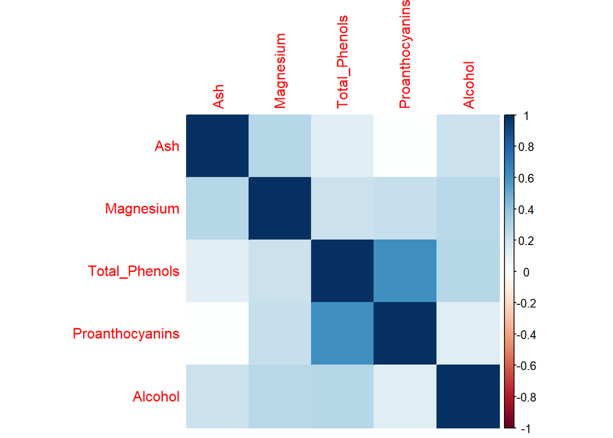

```r
# 1. Calculate variance of each feature
variances <- apply(wine, 2, var)

# 2. Select top 5 features with the highest variance
top_features <- names(sort(variances, decreasing = TRUE))[1:5]

# 3. Compute correlations for these top features
correlation_matrix <- cor(wine[, top_features])

# 4. Plot the correlation matrix
corrplot(correlation_matrix, method = "color")
```

```r
# 5. Select the least correlated features for clustering (avoid redundancy)
selected_features <- wine[, c("Proline", "Total_Phenols", "Color_Intensity")]
```

At this step, appropriate value of k is identified by 3 common methods, *Elbow Method*, *Average Silhouette Score*, and *Gap Statistics* namely. Generally, It is not necessary to apply all three methods Elbow Method, Silhouette Score, and Gap Statistic because they often provide overlapping insights. The Elbow Method and Silhouette Score already offer valuable perspectives on variance explained and cluster cohesion, making additional methods redundant in many cases. The Gap Statistic, while useful for validating clustering against random noise, is computationally intensive and may not be needed if the data shows clear structure. In practice, combining two complementary methods is usually sufficient to determine the optimal number of clusters efficiently.

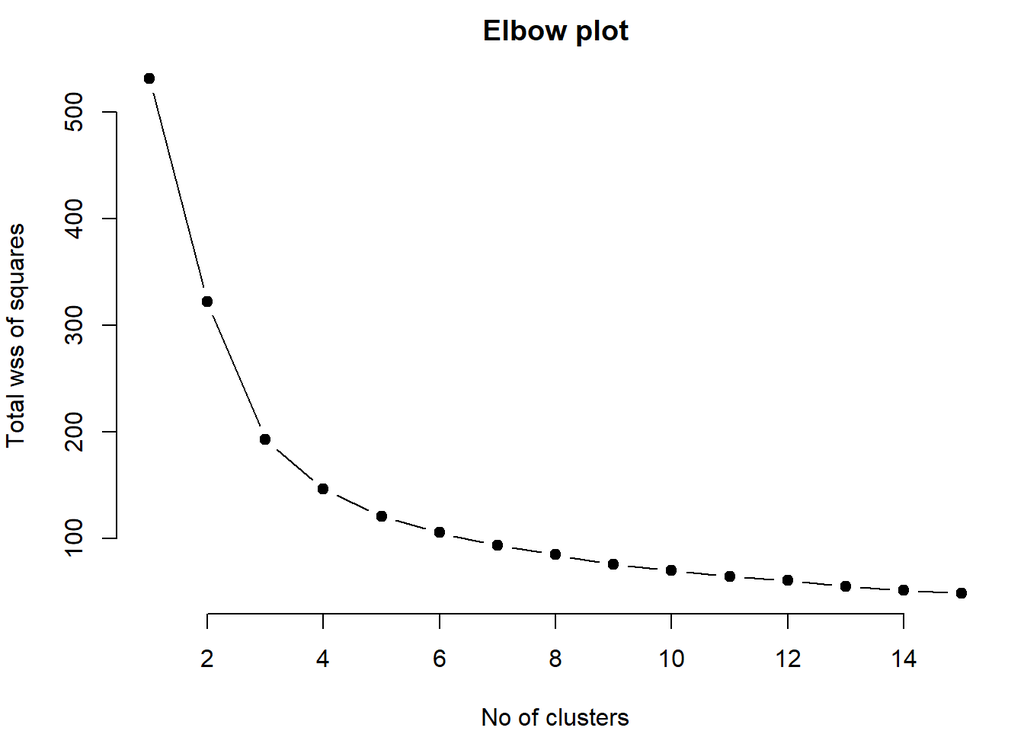

```r
# Elbow method
set.seed(100)
wss = function(k) {kmeans(selected_features, k, nstart=25)$tot.withinss}
k.values = 1:15
wss_values = map_dbl(k.values, wss)
par(mar = c(4, 4, 2, 1))
plot(k.values, wss_values, type="b", pch=19, frame=FALSE,
     main = "Elbow plot",
     xlab = "No of clusters",
     ylab = "Total wss of squares")
```

```
## Silhouette Score for k = 2 : 0.3839421
## Silhouette Score for k = 3 : 0.434431
## Silhouette Score for k = 4 : 0.3927743
## Silhouette Score for k = 5 : 0.3556266
## Silhouette Score for k = 6 : 0.3273394
## Silhouette Score for k = 7 : 0.3247825
## Silhouette Score for k = 8 : 0.3245555
## Silhouette Score for k = 9 : 0.321042
## Silhouette Score for k = 10 : 0.309851
```

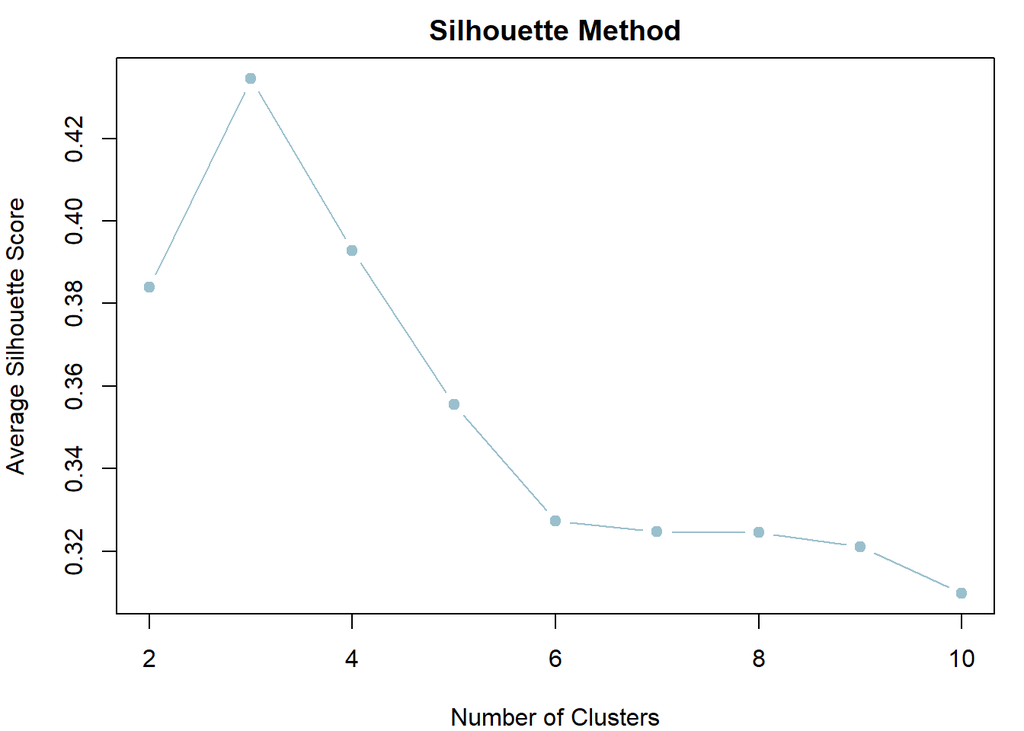

```r
# Silhouette Score
silhouette_calc <- function(selected_features, max_clusters = 10) {
  silhouette_score <- numeric(max_clusters - 1)  # Pre-allocate vector

  for (k in 2:max_clusters) {
    kmeans_out <- kmeans(selected_features, centers = k, nstart = 25)
    sil <- silhouette(kmeans_out$cluster, dist(selected_features))
    avg_sil <- mean(sil[, 3])  # Average silhouette width
    silhouette_score[k - 1] <- avg_sil
    cat("Silhouette Score for k =", k, ":", avg_sil, "\n")
  }

  # Plot Silhouette scores
  plot(2:max_clusters, silhouette_score, type = "b", pch = 19, col = "lightblue3",
       xlab = "Number of Clusters", ylab = "Average Silhouette Score",
       main = "Silhouette Method")
}
silhouette_calc(wine[, c("Proline", "Total_Phenols", "Color_Intensity")])
```

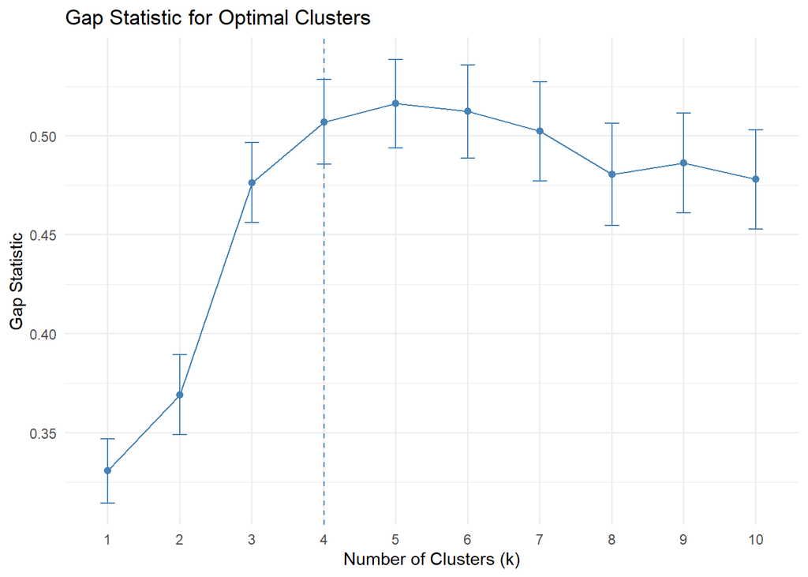

```r
# Gap statistic calculation
set.seed(123)  # For reproducibility
gap_stat <- clusGap(wine[, c("Proline", "Total_Phenols", "Color_Intensity")], FUN = kmeans, nstart = 25, K.max = 10, B = 50)

# Plot the Gap Statistic
fviz_gap_stat(gap_stat) +
  labs(title = "Gap Statistic for Optimal Clusters",
       x = "Number of Clusters (k)",
       y = "Gap Statistic") +
  theme_minimal()
```

From the plots, It can be observed that Elbow Method suggests 3 as an appropriate value of k, while Average Silhouette Score also says 3. According Gap Statistics on the other hand, the optimal number of clusters is 4 . Clustering is to be done according to the suggested values of k and plots will be observed to decide which cluster is more clear and cohesive.

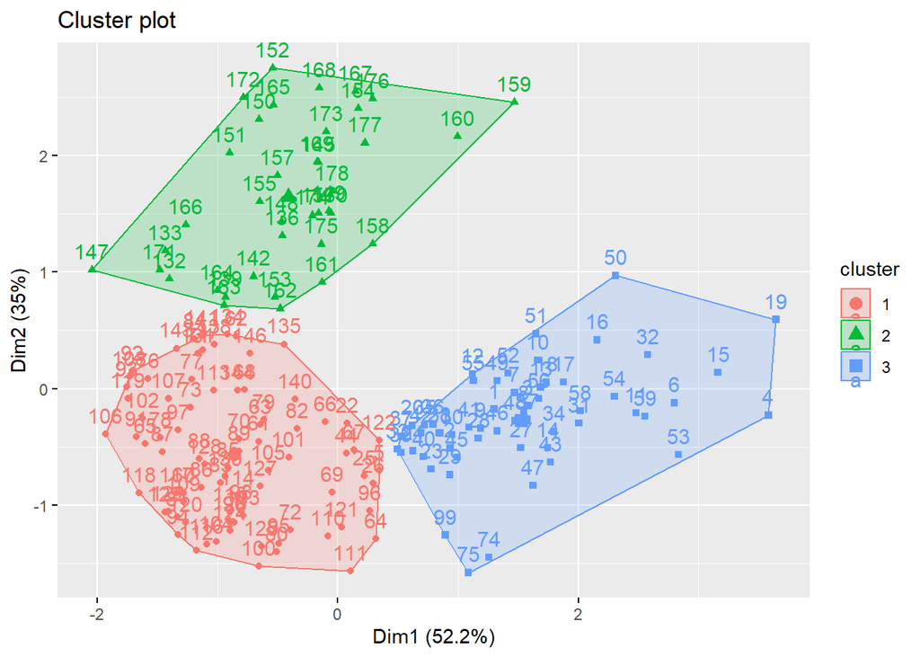

```r
# Elbow Method k = 3
kmeans_elbow <- kmeans(scale(selected_features), centers = 3, nstart = 25)
fviz_cluster(kmeans_elbow, data = selected_features)
```

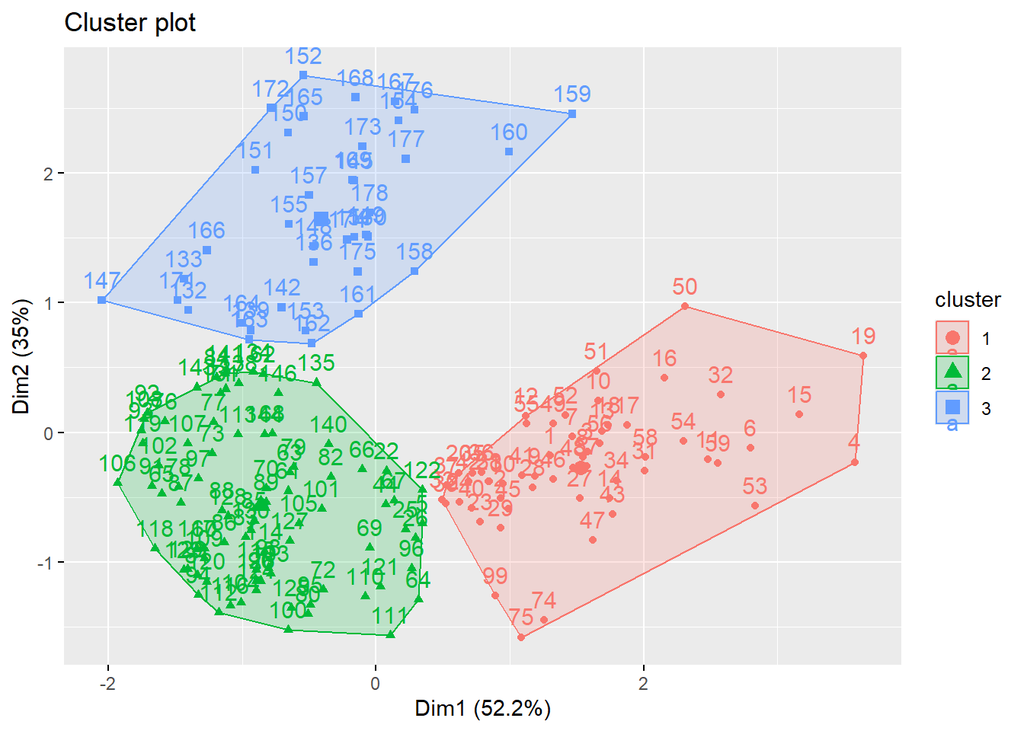

```r
# Average Silhouette Score k = 3
kmeans_silhouette <- kmeans(scale(selected_features), centers = 3, nstart = 25)
fviz_cluster(kmeans_silhouette, data = selected_features)
```

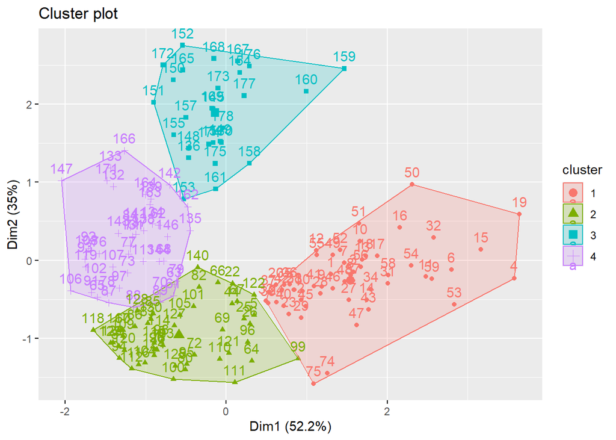

```r
# Gap Statistics k = 4
kmeans_gapst <- kmeans(scale(selected_features), centers = 4, nstart = 25)
fviz_cluster(kmeans_gapst, data = selected_features)
```

The cluster plots show different grouping scenarios, ranging from 3 to 4 clusters. The 3-cluster plot provides a balanced and refined grouping with clear separation, which aligns with the results from both the elbow and silhouette methods, indicating that 3 clusters may be the optimal choice. The 4-cluster plot introduces a finer distinction but shows some overlap, particularly between the green and purple clusters, and corresponds to the gap statistic’s suggestion of 4 clusters. The first dimension (`Dim1`) explains 52.2% of the variance, indicating it plays a dominant role in the separation. The spread-out points at the edges suggest potential outliers or transitional samples. The agreement between the elbow and silhouette methods supports the 3-cluster solution, while the gap statistic’s suggestion of 4 clusters may highlight subgrouping that requires further validation.

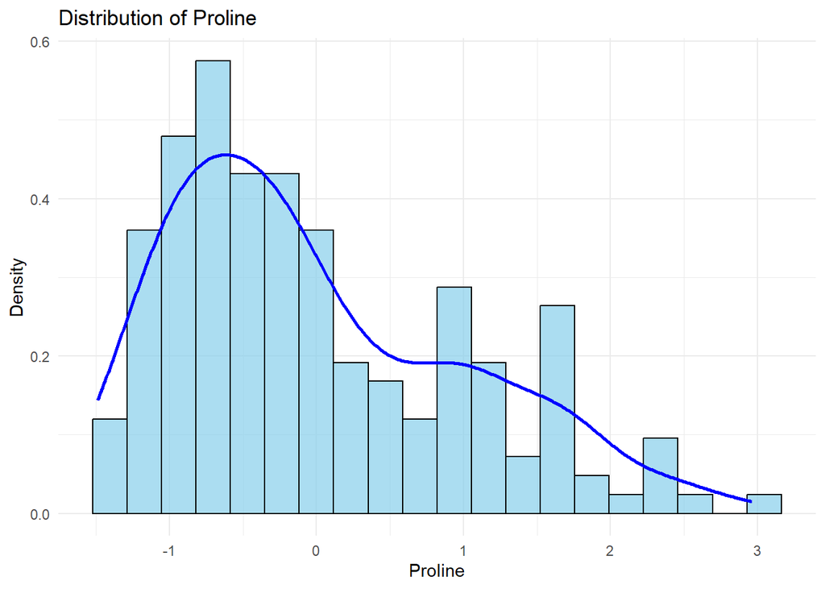

```r
# Histogram Density Curves
# Histogram for Proline
ggplot(wine, aes(x = Proline)) +
  geom_histogram(aes(y = ..density..), bins = 20, fill = "skyblue", color = "black", alpha = 0.7) +
  geom_density(color = "blue", size = 1) +
  ggtitle("Distribution of Proline") +
  xlab("Proline") +
  ylab("Density") +
  theme_minimal()
```

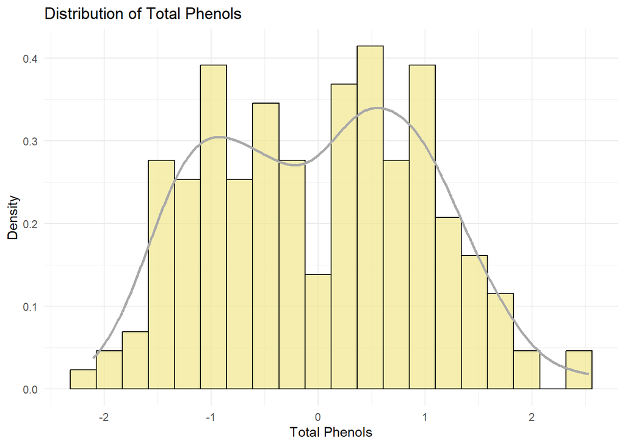

```r
# Histogram for Total_Phenols
ggplot(wine, aes(x = Total_Phenols)) +
  geom_histogram(aes(y = ..density..), bins = 20, fill = "khaki", color = "black", alpha = 0.7) +
  geom_density(color = "darkgrey", size = 1) +
  ggtitle("Distribution of Total Phenols") +
  xlab("Total Phenols") +
  ylab("Density") +
  theme_minimal()
```

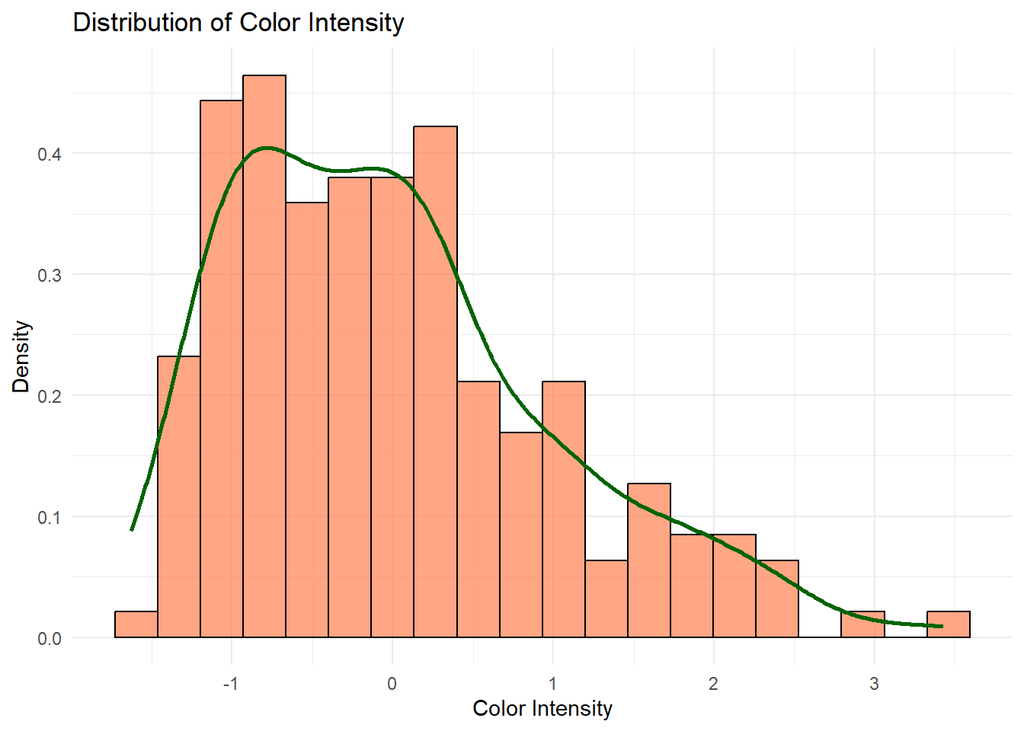

```r
# Histogram for Color_Intensity
ggplot(wine, aes(x = Color_Intensity)) +
  geom_histogram(aes(y = ..density..), bins = 20, fill = "coral", color = "black", alpha = 0.7) +
  geom_density(color = "darkgreen", size = 1) +
  ggtitle("Distribution of Color Intensity") +
  xlab("Color Intensity") +
  ylab("Density") +
  theme_minimal()
```

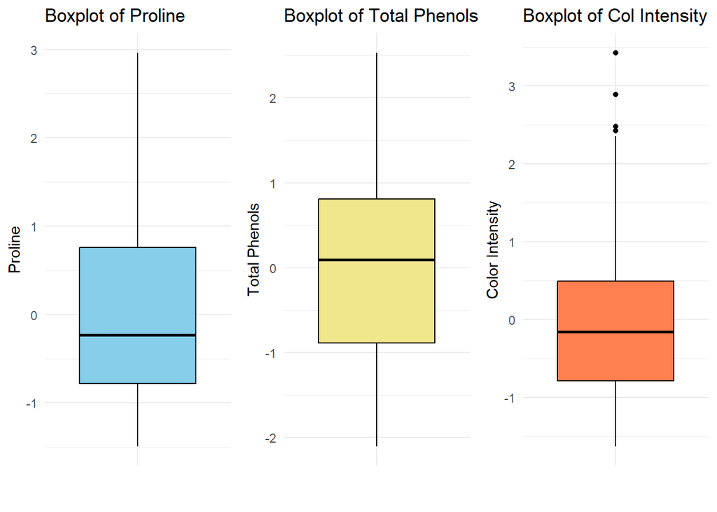

```r
# Boxplots
# Boxplot for Proline
p1 <- ggplot(wine, aes(x = "", y = Proline)) +
  geom_boxplot(fill = "skyblue", color = "black") +
  ggtitle("Boxplot of Proline") +
  xlab("") +
  ylab("Proline") +
  theme_minimal()

# Boxplot for Total_Phenols
p2 <- ggplot(wine, aes(x = "", y = Total_Phenols)) +
  geom_boxplot(fill = "khaki", color = "black") +
  ggtitle("Boxplot of Total Phenols") +
  xlab("") +
  ylab("Total Phenols") +
  theme_minimal()

# Boxplot for Color_Intensity
p3 <- ggplot(wine, aes(x = "", y = Color_Intensity)) +
  geom_boxplot(fill = "coral", color = "black") +
  ggtitle("Boxplot of Col Intensity") +
  xlab("") +
  ylab("Color Intensity") +
  theme_minimal()
# Arrange plots in a single row
grid.arrange(p1, p2, p3, ncol = 3)
```

```r
# Mean values of each cluster (Elbow Method)
means <- aggregate(wine_1[, c("Proline", "Total_Phenols", "Color_Intensity")], by = list
                   (cluster = kmeans_elbow$cluster), FUN = mean)
print(round(means, 2))
```

```
##   cluster Proline Total_Phenols Color_Intensity
## 1       1  535.17          2.17            3.30
## 2       2  632.37          1.67            8.14
## 3       3 1131.54          2.89            5.56
```

# Literature Review

## Authors

1. Gareth James
2. Daniela Witten
3. Trevor Hastie
4. Robert Tibshirani

## [*An Introduction to Statistical Learning with Applications in R*](https://www.statlearning.com/)

### Key findings from the literature

*Why Unsupervised Learning is challenging?*

Unsupervised learning is often much more challenging. In fact, the exercise tends to be more subjective, and there is no simple goal for the analysis, such as prediction of a response. Unsupervised learning is often performed as part of an exploratory data analysis. Furthermore, it can bee hard to assess the results obtained from unsupervised learning methods, since there is no universally accepted mechanism for performing cross validation or validating results on an independent data set. The reason for this difference is simple. If we fit a predictive model using a supervised learning technique, then it is possible to check our work by seeing how well our model predicts the response *Y* on observations not used in fitting the model. However, in unsupervised learning, there is no way to check our work because we don’t know the true answer—the problem is unsupervised.

*Why K-Means?*

*K*-means clustering is a simple and elegant approach for partitioning a data set into *K* distinct, non-overlapping clusters. To perform *K*-means clustering, we must first specify the desired number of clusters *K*; then the *K*-means algorithm will assign each observation to exactly one of the *K* clusters. The idea behind *K*-means clustering is that a good clustering is one for which the within-cluster variation is as small as possible. The within-cluster variation for cluster C is a measure W(C) of the amount by which the observations within a cluster differ from each other.

*What is important in K-Means Clustering?*

Because the K-means algorithm finds a local rather than a global optimum, the results obtained will depend on the initial (random) cluster assignment of each observation. For this reason, it is important to run the algorithm multiple times from different random initial configurations. Then one selects the best solution that for which the *within-cluster variation* is smallest.